# Filtering Mobile Phone Spam Using Naive Bayessian Method

This is a little implementation that can filter out spam from sms messages. The dataset is provided and made available to public under SMS Spam Collection, and can be downloaded at http://www.dt.fee.unicamp.br/~tiago/smsspamcollection/ . This dataset contains a bunch of sms messages. Junk messages have been labled as “spam” and legit messages as “ham”. The task is to train a Bayesian machine learning system to filter out “spam” sms.

#### Step 1: Reading in the dataset

```r
# NOTE: the dataset has been modified slightly so that it can be easier to work with
sms_raw <- read.csv('sms_spam.csv', stringsAsFactors = FALSE)
```

#### Step 2: Exploring and preparing data

```r
str(sms_raw) # structure of dataset
```

```
'data.frame':   5559 obs. of  2 variables:
 $ type: chr  "ham" "ham" "ham" "spam" ...
 $ text: chr  "Hope you are having a good week. Just checking in" "K..give back my thanks." "Am also doing in cbe only. But have to pay." "complimentary 4 STAR Ibiza Holiday or ÃÂ£10,000 cash needs your URGENT collection. 09066364349 NOW from Landline not to lose out"| __truncated__ ...
```

```r
sms_raw$type <- factor(sms_raw$type) # convert $type into factor variable
str(sms_raw) # structure of dataset
```

```
'data.frame':   5559 obs. of  2 variables:
 $ type: Factor w/ 2 levels "ham","spam": 1 1 1 2 2 1 1 1 2 1 ...
 $ text: chr  "Hope you are having a good week. Just checking in" "K..give back my thanks." "Am also doing in cbe only. But have to pay." "complimentary 4 STAR Ibiza Holiday or ÃÂ£10,000 cash needs your URGENT collection. 09066364349 NOW from Landline not to lose out"| __truncated__ ...
```

```r
table(sms_raw$type)
```

```
 ham spam
4812  747
```

##### To prepare and standradize text, we need to install and load *‘tm’* package: *‘tm’* is text mining package

```r
#install.packages("tm", dependencies = TRUE)
#install.packages("SnowballC") # this package help in stemming words; for ex: it makes "installed"", "installing"", and "installs"" become just "install""
library(tm)
library(SnowballC)
sms_corpus <- VCorpus(VectorSource(sms_raw$text)) # create a corpus for the text
print(sms_corpus)
```

```
<<VCorpus>>
Metadata:  corpus specific: 0, document level (indexed): 0
Content:  documents: 5559
```

```r
inspect(sms_corpus[1:2])
```

```
<<VCorpus>>
Metadata:  corpus specific: 0, document level (indexed): 0
Content:  documents: 2

[[1]]
<<PlainTextDocument>>
Metadata:  7
Content:  chars: 49

[[2]]
<<PlainTextDocument>>
Metadata:  7
Content:  chars: 23
```

```r
lapply(sms_corpus[1:2], as.character) # print out first 2 sms text
```

```
$`1`
[1] "Hope you are having a good week. Just checking in"

$`2`
[1] "K..give back my thanks."
```

```r
# We begin cleaning and standardizing the text messages in our corpus
# +transform all raw text to lowercase
sms_corpus_clean <- tm_map(sms_corpus, content_transformer(tolower))
lapply(sms_corpus[1:2], as.character) # print out first 2 sms text
```

```
$`1`
[1] "Hope you are having a good week. Just checking in"

$`2`
[1] "K..give back my thanks."
```

```r
lapply(sms_corpus_clean[1:2], as.character) # print out first 2 sms text
```

```
$`1`
[1] "hope you are having a good week. just checking in"

$`2`
[1] "k..give back my thanks."
```

```r
# + remove numbers from our corpus texts
sms_corpus_clean <- tm_map(sms_corpus_clean, removeNumbers)
# +remove stopwords sice they reveal little information about a text
sms_corpus_clean <- tm_map(sms_corpus_clean, removeWords, stopwords("english"))
# + remove punctuation
sms_corpus_clean <- tm_map(sms_corpus_clean, removePunctuation)
# + stems words in sms text to their root
sms_corpus_clean <- tm_map(sms_corpus_clean, stemDocument)
# + now remove whitespaces left behind from the cleaning process above
sms_corpus_clean <- tm_map(sms_corpus_clean, stripWhitespace)
```

##### Take look at the diffrence between the original corpus and modified corpus:

```r
lapply(sms_corpus[1:10], as.character)
```

```
$`1`
[1] "Hope you are having a good week. Just checking in"

$`2`
[1] "K..give back my thanks."

$`3`
[1] "Am also doing in cbe only. But have to pay."

$`4`
[1] "complimentary 4 STAR Ibiza Holiday or ÃÂ£10,000 cash needs your URGENT collection. 09066364349 NOW from Landline not to lose out! Box434SK38WP150PPM18+"

$`5`
[1] "okmail: Dear Dave this is your final notice to collect your 4* Tenerife Holiday or #5000 CASH award! Call 09061743806 from landline. TCs SAE Box326 CW25WX 150ppm"

$`6`
[1] "Aiya we discuss later lar... Pick u up at 4 is it?"

$`7`
[1] "Are you this much buzy"

$`8`
[1] "Please ask mummy to call father"

$`9`
[1] "Marvel Mobile Play the official Ultimate Spider-man game (ÃÂ£4.50) on ur mobile right now. Text SPIDER to 83338 for the game & we ll send u a FREE 8Ball wallpaper"

$`10`
[1] "fyi I'm at usf now, swing by the room whenever"
```

```r
lapply(sms_corpus_clean[1:10], as.character)
```

```
$`1`
[1] "hope good week just check"

$`2`
[1] "kgive back thank"

$`3`
[1] " also cbe pay"

$`4`
[1] "complimentari star ibiza holiday Ã¢ cash need urgent collect now landlin lose boxskwpppm"

$`5`
[1] "okmail dear dave final notic collect tenerif holiday cash award call landlin tcs sae box cwwx ppm"

$`6`
[1] "aiya discuss later lar pick u "

$`7`
[1] " much buzi"

$`8`
[1] "pleas ask mummi call father"

$`9`
[1] "marvel mobil play offici ultim spiderman game Ã¢ ur mobil right now text spider game ll send u free ball wallpap"

$`10`
[1] "fyi usf now swing room whenev"
```

##### Splitting corpus into individual words:

We have to create a Document-Term-Matrix which is basically a table that has the text messages as rows and thw words in the corpus as column.

```r
sms_dtm <- DocumentTermMatrix(sms_corpus_clean)
inspect(sms_dtm[1:30,815:825]) # take a peek at the new DTM
```

```
<<DocumentTermMatrix (documents: 30, terms: 11)>>
Non-/sparse entries: 4/326
Sparsity           : 99%
Maximal term length: 11
Weighting          : term frequency (tf)

    Terms
Docs california call callback callcost callcoz calld calldrov caller callertun callfreefon callin
  1           0    0        0        0       0     0        0      0         0           0      0
  2           0    0        0        0       0     0        0      0         0           0      0
  3           0    0        0        0       0     0        0      0         0           0      0
  4           0    0        0        0       0     0        0      0         0           0      0
  5           0    1        0        0       0     0        0      0         0           0      0
  6           0    0        0        0       0     0        0      0         0           0      0
  7           0    0        0        0       0     0        0      0         0           0      0
```

[output cut: 23 more lines]

##### Now we create a training and test dataset:

```r
# split our DocumentTermMatrix into test and training dataset
sms_dtm_train <- sms_dtm[1:4169, ]
sms_dtm_test <- sms_dtm[4170:5559, ]
# also append a labels column from the raw dataframe
sms_train_labels <- sms_raw[1:4169, ]$type
sms_test_labels <- sms_raw[4170:5559, ]$type
prop.table(table(sms_train_labels)) # show percentage of ham and spam in training dataset
```

```
sms_train_labels
      ham      spam
0.8647158 0.1352842
```

```r
prop.table(table(sms_test_labels)) # show percentage of ham and spam in test dataset
```

```
sms_test_labels
      ham      spam
0.8683453 0.1316547
```

##### Visualizing text using word clouds:

A word clouds is a visualiztion technique that display words randomly or orderedly in a cloud, words with higher frequency will appear lager than the ones with lower frequency

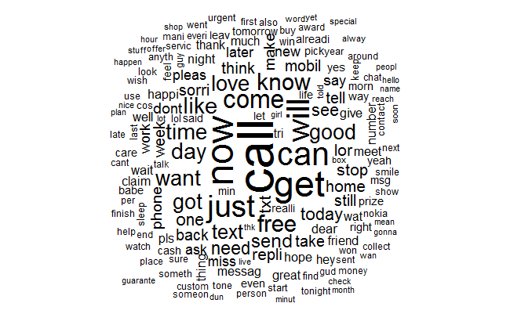

```r
#install.packages("wordcloud")
library(wordcloud)
wordcloud(sms_corpus_clean, min.freq = 50, scale = c(4,.4), random.order = FALSE)
```

It’s also very helpful to compare the wordclouds between spam and ham messages

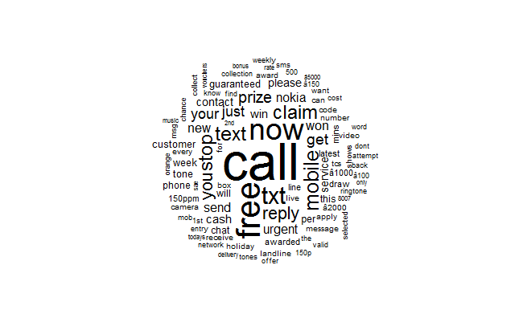

```r
spam <- subset(sms_raw, type == "spam")
ham <- subset(sms_raw, type == "ham")
wordcloud(spam$text, min.freq = 20, scale = c(4,0.3), random.order = FALSE)
```

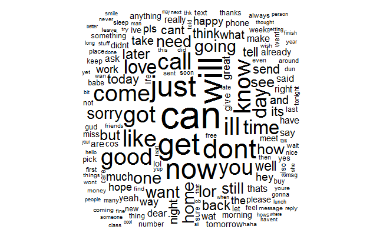

```r
wordcloud(ham$text, min.freq = 40, scale = c(4,0.1), random.order = FALSE)
```

##### The last step of data preparation is to create indicator features for the most frequent words:

```r
sms_fre_words <- findFreqTerms(sms_dtm_train, 5) # find terms that has at least 5 appearances
str(sms_fre_words) # let's see how many frequent words we have
```

```
 chr [1:1139] "Ã¢âÃ¢â¬Å""| __truncated__ "abiola" "abl" "abt" "accept" "access" "account" "across" "act" "activ" ...
```

So we have reduced the number of features from over 6500 down to 1139 by only accepting words with frequency = 5 of higher. Now we use this chr vector to filter out our DTM

```r
sms_dtm_freq_train <- sms_dtm_train[ , sms_fre_words]
sms_dtm_freq_test <- sms_dtm_test[ , sms_fre_words]
```

Since Bayes classifier works on categorical dataset and our test and train dataset contains numeric values, we have to covnert these dataset into categorical variable by setting the variables to “yes”" or “no” depending on if it appear in each message.

```r
convert_counts <- function(x){
  x <- ifelse(x >0, "Yes", "No") # if the word appear in a text message, then change its value to Yes, otherwise, No
}
sms_train <- apply(sms_dtm_freq_train, MARGIN = 2, convert_counts)
sms_test <- apply(sms_dtm_freq_test, MARGIN = 2, convert_counts)
```

#### Step 3: Training Naive Bayes Classifier

This Naive Bayes classifier will estimate the probability of whether a text message is a spam or ham base on the presence and absence of words in a text. The Naive Bayes classifier used is from ‘e1071’ package developed by Vienna University of Technology

```r
#install.packages('e1071')
library(e1071)
sms_classifier <- naiveBayes(sms_train, sms_train_labels)
```

#### Step 4: Evaluating the performance of our Naive Bayes classifier

```r
# perform prediction on the test dataset using the resulted Naive Bayes classifier
sms_test_pred <- predict(sms_classifier, sms_test)
# elvaluate model's performance with CrossTable
library(gmodels)
CrossTable(sms_test_pred, sms_test_labels, prop.chisq = FALSE, prop.t = FALSE, dnn = c("Predicted", "Actual"))
```

```
   Cell Contents
|-------------------------|
|                       N |
|           N / Row Total |
|           N / Col Total |
|-------------------------|


Total Observations in Table:  1390


             | Actual
   Predicted |       ham |      spam | Row Total |
-------------|-----------|-----------|-----------|
         ham |      1201 |        30 |      1231 |
             |     0.976 |     0.024 |     0.886 |
             |     0.995 |     0.164 |           |
-------------|-----------|-----------|-----------|
        spam |         6 |       153 |       159 |
             |     0.038 |     0.962 |     0.114 |
             |     0.005 |     0.836 |           |
-------------|-----------|-----------|-----------|
Column Total |      1207 |       183 |      1390 |
             |     0.868 |     0.132 |           |
-------------|-----------|-----------|-----------|
```

#### Step 4: Improving our Naive Bayes classifier performance

```r
# using laplace estimator to improve accuracy
sms_classifier2 <- naiveBayes(sms_train, sms_train_labels, laplace = 1)
sms_test_pred2 <- predict(sms_classifier2, sms_test)
CrossTable(sms_test_pred2, sms_test_labels, prop.chisq = FALSE, prop.t = FALSE, prop.r = FALSE, dnn = c("Predicted", "Actual"))
```

```
   Cell Contents
|-------------------------|
|                       N |
|           N / Col Total |
|-------------------------|


Total Observations in Table:  1390


             | Actual
   Predicted |       ham |      spam | Row Total |
-------------|-----------|-----------|-----------|
         ham |      1202 |        28 |      1230 |
             |     0.996 |     0.153 |           |
-------------|-----------|-----------|-----------|
        spam |         5 |       155 |       160 |
             |     0.004 |     0.847 |           |
-------------|-----------|-----------|-----------|
Column Total |      1207 |       183 |      1390 |
             |     0.868 |     0.132 |           |
-------------|-----------|-----------|-----------|
```

Let’s try to increase laplace estimator to see how it changes the accuracy + with laplace estimator = 2

```r
sms_classifier3 <- naiveBayes(sms_train, sms_train_labels, laplace = 2)
sms_test_pred3 <- predict(sms_classifier3, sms_test)
CrossTable(sms_test_pred3, sms_test_labels, prop.chisq = FALSE, prop.t = FALSE, prop.r = FALSE, dnn = c("Predicted", "Actual"))
```

```
   Cell Contents
|-------------------------|
|                       N |
|           N / Col Total |
|-------------------------|


Total Observations in Table:  1390


             | Actual
   Predicted |       ham |      spam | Row Total |
-------------|-----------|-----------|-----------|
         ham |      1204 |        34 |      1238 |
             |     0.998 |     0.186 |           |
-------------|-----------|-----------|-----------|
        spam |         3 |       149 |       152 |
             |     0.002 |     0.814 |           |
-------------|-----------|-----------|-----------|
Column Total |      1207 |       183 |      1390 |
             |     0.868 |     0.132 |           |
-------------|-----------|-----------|-----------|
```

- with laplace estimator = 3

```r
sms_classifier4 <- naiveBayes(sms_train, sms_train_labels, laplace = 3)
sms_test_pred4 <- predict(sms_classifier4, sms_test)
CrossTable(sms_test_pred4, sms_test_labels, prop.chisq = FALSE, prop.t = FALSE, prop.r = FALSE, dnn = c("Predicted", "Actual"))
```

```
   Cell Contents
|-------------------------|
|                       N |
|           N / Col Total |
|-------------------------|


Total Observations in Table:  1390


             | Actual
   Predicted |       ham |      spam | Row Total |
-------------|-----------|-----------|-----------|
         ham |      1202 |        40 |      1242 |
             |     0.996 |     0.219 |           |
-------------|-----------|-----------|-----------|
        spam |         5 |       143 |       148 |
             |     0.004 |     0.781 |           |
-------------|-----------|-----------|-----------|
Column Total |      1207 |       183 |      1390 |
             |     0.868 |     0.132 |           |
-------------|-----------|-----------|-----------|
```

- with laplace estimator = 4

```r
sms_classifier5 <- naiveBayes(sms_train, sms_train_labels, laplace = 4)
sms_test_pred5 <- predict(sms_classifier5, sms_test)
CrossTable(sms_test_pred5, sms_test_labels, prop.chisq = FALSE, prop.t = FALSE, prop.r = FALSE, dnn = c("Predicted", "Actual"))
```

```
   Cell Contents
|-------------------------|
|                       N |
|           N / Col Total |
|-------------------------|


Total Observations in Table:  1390


             | Actual
   Predicted |       ham |      spam | Row Total |
-------------|-----------|-----------|-----------|
         ham |      1202 |        46 |      1248 |
             |     0.996 |     0.251 |           |
-------------|-----------|-----------|-----------|
        spam |         5 |       137 |       142 |
             |     0.004 |     0.749 |           |
-------------|-----------|-----------|-----------|
Column Total |      1207 |       183 |      1390 |
             |     0.868 |     0.132 |           |
-------------|-----------|-----------|-----------|
```

==> It seems that with laplace estimator = 1, our Naive Bayes classifier is the most accurate. We also observed that, by increasing laplace estimator, the number of spam messagees incorrectly identified as “ham” increases. This shows that it is important to pick the right laplace estimator so that our Naive Bayes classifier does not filter out spam too aggresively (which leads to ham misclassified as “spam”) or too passively (which causes spam misclassified as “ham”)!

#### Reference:

*Machine Learning with R* by Brett Lantz.